# “La importancia del rol de las instituciones de representación popular para el mantenimiento de la democracia en Chile

Nicolás Fuentes Contreras

2022-12-05

[figure not shown]

#### Universidad Alberto Hurtado

#### Carrera: Ciencia Política y Relaciones Internacionales

#### Profesora: Valentina Andrade de la Horra

#### Ayudantes: Dafne Jaime Vargas

#### Estudiante: Nicolás Fuentes Contreras

### Abstract:

```
Históricamente, la democracia ha tenido distintas denominaciones y dimensiones, en donde, una de ellas es la democracia representativa. Esta última, caracterizada por el rol fundamental de representatividad que se le asocia a la relación ciudadano-gobernante; teniendo que, un valor indispensable par…
```

##### Keywords: Democracia, confianza, instituciones de representacion popular, representatividad

### Introducción:

```
Según Rubén Hernández (2002) la democracia representativa es aquella en que se identifica la voluntad de los representantes del pueblo soberano con la de sus representantes electos. En ese sentido, parte de aquella representatividad radica en la confianza que entregan los ciudadanos en sus represent…

En ese sentido, la problemática que guía la presente investigación es: la confianza que tienen las personas en las instituciones de representación popular como el gobierno, el congreso y los partidos políticos ¿afecta considerablemente en el nivel de satisfacción que las personas tienen de la democr…
```

### Análisis:

#### Primer apartado: carga de paquetes

```r
pacman::p_load(tidyverse,
               sjmisc,
               srvyr,
               survey,
               forcats,
               car,
               haven,
               dplyr,
               car,
               sjmisc,
               sjlabelled,
               sjPlot)
```

#### Segundo apartado: carga de la base de datos

```r
Datos_proc <- readRDS(file = "output/data/Datos_proc.rds")
```

#### Tercer apartado: creación de objeto encuesta

```r
objeto_encuesta <- Datos_proc %>%
  as_survey_design(ids = idencuesta,
                   weights = exp)
```

#### Cuarto apartado: modelos y análisis de regresión lineal múltiple

```
Para efectos exclusivos de la investigación se optó por recodificar la variable *democracia* y las variables *confianza_gobierno*, *confianza_congreso*, *confianza_partidos* a partir de únicamente dos valores de respuesta. Mientras que, las variables restantes como *tramo_edad* se recodificó a parti…

Variables:
1. Variable dependiente: democracia
2. Variables independientes: confianza_gobierno + confianza_congreso + confianza_partidos + tramo_edad + sexo
```

#### *Modelo 1*

##### Análisis de regresión con las variables relacionadas a la confianza en el Gobierno, Congreso y Partidos Políticos

```r
modelo_1 <- glm(democracia ~ confianza_gobierno + confianza_congreso + confianza_partidos,
                family = gaussian(link = "identity"),
                data = Datos_proc)
```

##### Parámetros

```r
summary(modelo_1)
```

```
##
## Call:
## glm(formula = democracia ~ confianza_gobierno + confianza_congreso +
##     confianza_partidos, family = gaussian(link = "identity"),
##     data = Datos_proc)
##
## Deviance Residuals:
##     Min       1Q   Median       3Q      Max
## -0.8031  -0.3308   0.1969   0.1969   0.8033
##
## Coefficients:
##                    Estimate Std. Error t value Pr(>|t|)
## (Intercept)         0.59029    0.06097   9.682  < 2e-16 ***
## confianza_gobierno  0.30591    0.02116  14.454  < 2e-16 ***
## confianza_congreso  0.16640    0.02272   7.324 3.18e-13 ***
## confianza_partidos  0.13411    0.03355   3.997 6.59e-05 ***
## ---
## Signif. codes:  0 '***' 0.001 '**' 0.01 '*' 0.05 '.' 0.1 ' ' 1
##
## (Dispersion parameter for gaussian family taken to be 0.1822577)
##
##     Null deviance: 583.10  on 2670  degrees of freedom
## Residual deviance: 486.08  on 2667  degrees of freedom
##   (69 observations deleted due to missingness)
## AIC: 3039
##
## Number of Fisher Scoring iterations: 2
```

### Tabla primer modelo con variables de confianza

Análisis de regresión con variables de confianza

Modelo 1

Predictores

β

(Intercept)

0.59 ***

Grado de confianza: El  
gobierno

0.31 ***

Grado de confianza: El  
Congreso Nacional

0.17 ***

Grado de confianza: Los  
partidos políticos

0.13 ***

Observations

2671

R<sup>2</sup>

0.166

- p<0.05 ** p<0.01 *** p<0.001

#### Gráfico del Modelo 1 de regresión

[figure not shown]

```r
sjPlot::plot_model(modelo_1,
                   show.p = T,
                   show.values =  T,
                   ci.lvl = c(0.95),
                   title = "Gráfico N°1",
                   vline.color = "blue")
```

#### *Modelo 2*

##### Análisis de regresión con las variables relacionadas a la confianza, edad y sexo

```r
modelo_2 <- glm(democracia ~ confianza_gobierno + confianza_congreso + confianza_partidos + sexo + tramo_edad,
                family = gaussian(link = "identity"),
                data = Datos_proc)
```

##### Parámetros

```r
summary(modelo_2)
```

```
##
## Call:
## glm(formula = democracia ~ confianza_gobierno + confianza_congreso +
##     confianza_partidos + sexo + tramo_edad, family = gaussian(link = "identity"),
##     data = Datos_proc)
##
## Deviance Residuals:
##     Min       1Q   Median       3Q      Max
## -0.8278  -0.3435   0.1809   0.2591   0.8625
##
## Coefficients:
##                         Estimate Std. Error t value Pr(>|t|)
## (Intercept)            0.5350522  0.0628163   8.518  < 2e-16 ***
## confianza_gobierno     0.3110872  0.0211729  14.693  < 2e-16 ***
## confianza_congreso     0.1644941  0.0226850   7.251 5.39e-13 ***
## confianza_partidos     0.1268731  0.0335538   3.781 0.000160 ***
## sexoMujer              0.0008952  0.0170996   0.052 0.958250
## tramo_edadAdulto       0.0782119  0.0209273   3.737 0.000190 ***
## tramo_edadAdulto mayor 0.0869442  0.0234669   3.705 0.000216 ***
## ---
## Signif. codes:  0 '***' 0.001 '**' 0.01 '*' 0.05 '.' 0.1 ' ' 1
##
## (Dispersion parameter for gaussian family taken to be 0.1812946)
##
##     Null deviance: 583.10  on 2670  degrees of freedom
## Residual deviance: 482.97  on 2664  degrees of freedom
##   (69 observations deleted due to missingness)
## AIC: 3027.9
##
## Number of Fisher Scoring iterations: 2
```

### Comparación de los modelos 1 y 2

Análisis de regresión: comparación de modelos 1 y 2

Modelo 1

modelo 2

Predictores

β

β

(Intercept)

0.59 ***

0.54 ***

Grado de confianza: El  
gobierno

0.31 ***

0.31 ***

Grado de confianza: El  
Congreso Nacional

0.17 ***

0.16 ***

Grado de confianza: Los  
partidos políticos

0.13 ***

0.13 ***

Sexo de la persona  
entrevistada: Mujer

0.00

Edad de la persona  
entrevistada en tramos:  
Adulto

0.08 ***

Edad de la persona  
entrevistada en tramos:  
Adulto mayor

0.09 ***

Observations

2671

2671

R<sup>2</sup>

0.166

0.172

- p<0.05 ** p<0.01 *** p<0.001

#### Gráfico del Modelo 2 de regresión

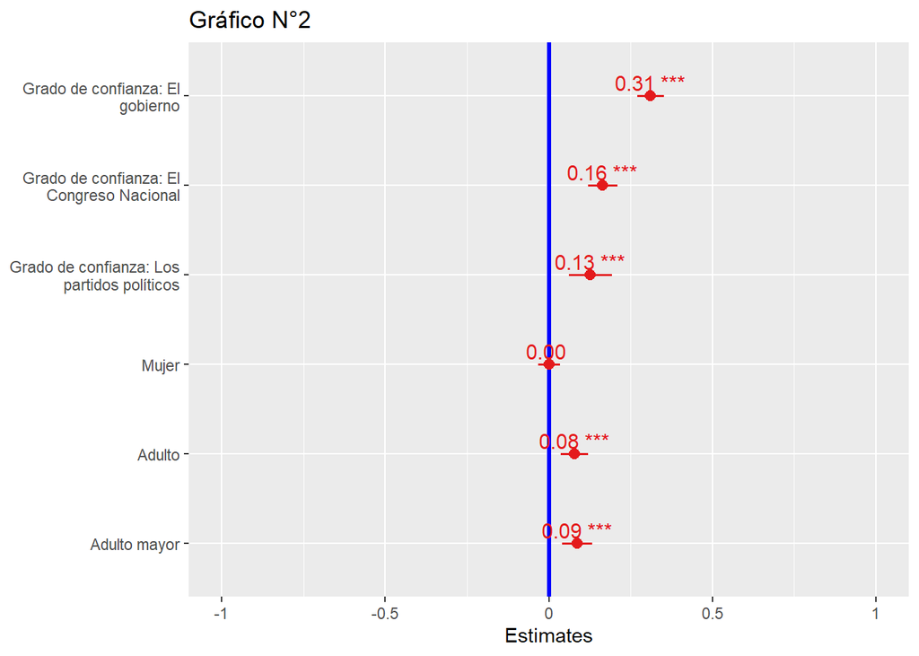

```r
sjPlot::plot_model(modelo_2,
                   show.p = T,
                   show.values =  T,
                   ci.lvl = c(0.95),
                   title = "Gráfico N°2",
                   vline.color = "blue")
```

#### *Modelo 3*

##### Modelo de regresión con diseño complejo: todas las variables

```r
modelo_3_survey <- svyglm(democracia ~ confianza_gobierno + confianza_congreso +
                        confianza_partidos + sexo + tramo_edad,
                        family = gaussian(link = "identity"),
                        design = objeto_encuesta,
                        data = Datos_proc)
```

### Tabla del modelo 3

Análisis de regresión: Modelo 3

Modelo 3

Predictores

β

(Intercept)

0.49 ***

Grado de confianza: El  
gobierno

0.35 ***

Grado de confianza: El  
Congreso Nacional

0.20 ***

Grado de confianza: Los  
partidos políticos

0.09

Sexo de la persona  
entrevistada: Mujer

-0.02

Edad de la persona  
entrevistada en tramos:  
Adulto

0.07

Edad de la persona  
entrevistada en tramos:  
Adulto mayor

0.09 **

Observations

2671

R<sup>2</sup> / R<sup>2</sup> adjusted

0.212 / 0.210

- p<0.05 ** p<0.01 *** p<0.001

#### Parámetros

```r
summary(modelo_3_survey)
```

```
##
## Call:
## svyglm(formula = democracia ~ confianza_gobierno + confianza_congreso +
##     confianza_partidos + sexo + tramo_edad, design = objeto_encuesta,
##     family = gaussian(link = "identity"), data = Datos_proc)
##
## Survey design:
## Called via srvyr
##
## Coefficients:
##                        Estimate Std. Error t value Pr(>|t|)
## (Intercept)             0.49288    0.09592   5.139 2.97e-07 ***
## confianza_gobierno      0.35107    0.03795   9.251  < 2e-16 ***
## confianza_congreso      0.20133    0.04090   4.923 9.04e-07 ***
## confianza_partidos      0.08640    0.05118   1.688  0.09152 .
## sexoMujer              -0.01674    0.03122  -0.536  0.59187
## tramo_edadAdulto        0.06719    0.03677   1.827  0.06779 .
## tramo_edadAdulto mayor  0.09313    0.03418   2.724  0.00648 **
## ---
## Signif. codes:  0 '***' 0.001 '**' 0.01 '*' 0.05 '.' 0.1 ' ' 1
##
## (Dispersion parameter for gaussian family taken to be 0.1733012)
##
## Number of Fisher Scoring iterations: 2
```

```
Considerando los resultados entregados se puede mencionar que el Modelo 3 de regresión, el modelo tiene capacidad explicativa a un 99$% de confianza. Por otro lado, al ser una regresión múltiple tenemos que R^2-adjusted se ajusta bastante bien al valor de R^2, teniendo los valores de 0,210(R^2-adjus…

Cabe mencionar que al incluir las variables sexo y tramo_edad, no hay un gran cambio en la significancia del modelo, pues sigue siendo significativo a un 99% de confianza. Pero, considerando el primer modelo, la varianza con la cual explican las variables de confianza en la satisfacción con la democ…

Finalmente, si bien en la presente investigación se buscaba realizar solamente un análisis de regresión múltiple incluyendo las variables relacionadas a confianza, sexo y edad, relacionando los presentes resultados con los resultados entregados por la encuesta CEP (2021), se puede hace un símil de a…
```

### Conclusiones:

```
Finalmente, a modo de conclusión, se puede establecer que, si existe un efecto por parte de las variables relacionadas a la confianza en el gobierno, el congreso y los partidos políticos, en la satisfacción de las personas con la democracia en Chile. Asimismo, cabe mencionar que, a partir de la info…

Considerando lo anterior, es sumamente importante cambiar el paradigma de representación en Chile, en donde como foco principal prime la accountability y la probidad, generando así una relación más cercana de los ciudadanos con las instituciones, en este caso, los mismos funcionarios públicos. De ta…
```

### Referencias:

```
Encuesta Nacional de Opinión Pública: Encuesta especial Covid (Abril, 2021). Presentación de los resultados. Recuperado de: https://www.cepchile.cl/cep/encuestas-cep/encuestas-2010-2021/1-encuesta-especial-cep-abril-2021

Garrido, M. (2021). Encuesta CEP: PDI lidera confianza en instituciones. LA TERCERA. Extraído de :https://www.latercera.com/politica/noticia/encuesta-cep-pdi-lidera-confianza-en-instituciones/Y57QQCMKWFGKDNBFRB4VD4QK6A/#commentsLine

Segovia, C.; Haye, A., González, R., Manzi, J. & Carvacho, H. (2008). Confianza en instituciones políticas en Chile: un modelo de los componentes centrales de juicios de confianza. Revista de ciencia política (Santiago), 28(2), 39-60. Recuperado de: https://www.scielo.cl/scielo.php?script=sci_arttex…

Valle, R. H. (2002). De la democracia representativa a la democracia participativa. En, Anuario iberoamericano de justicia constitucional. Centro de Estudios Públicos y constitucionales. (6), 199-220.
```